# FINAL-PROJECT-FINAL slides

[figure not shown]

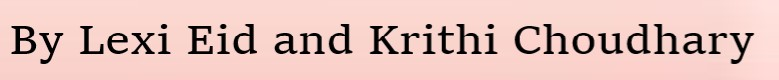

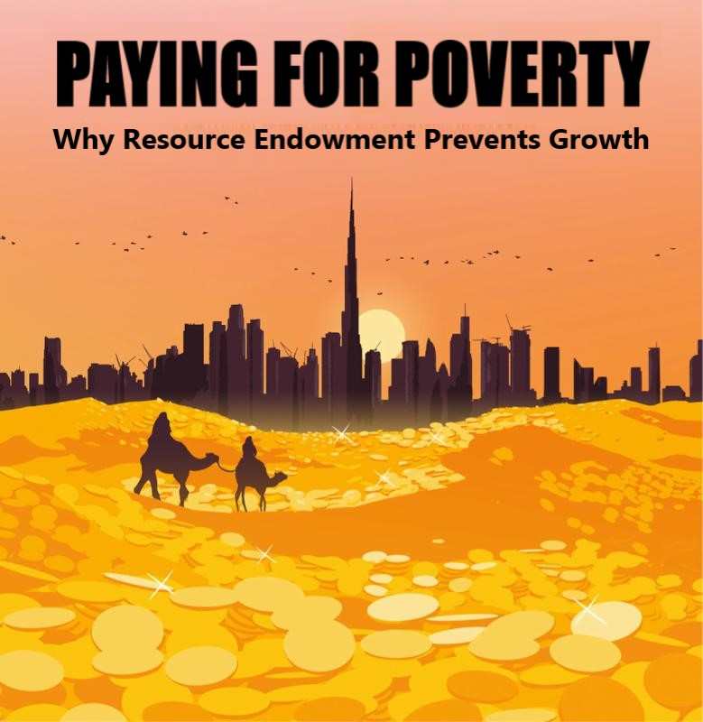

## Question/ Problem We’re Addressing

Beginning in the 1950s, scholars have reflected on the lack of development in low and middle-income countries. This correlation between lower income and slower growth was originally suspected to be a factor of path dependence, where a lack of wealth in the 1800s and 1900s could lead to a lack of growth in the 21st century. However, the 1980s demonstrated that lower-income countries CAN experience rapid economic growth, by a factor of more than 10% per year. In particular, the “miracle growth” countries like China, Korea, and Japan, categorized as countries with sustained economic growth of more than 6% per year, inspired further research. Still, the majority of low-income nations remained low-income. Some glaring exceptions also stood out: countries endowed with natural resources which should catalyze growth and integration into the international economy. Often, the results were counterintuitive to logic. These countries, endowed with oil, natural gas, and other high-value-added resources, experienced slower economic growth than their high-income counterparts and their low-income neighbors. In 1993, Richard Auty coined the term *resource curse* to describe this phenomenon of lower economic growth in resource-abundant countries.

The resource curse was inspired by another similar phenomenon, the Dutch disease. The Dutch disease suggests that increased exports of natural resources instigated a decline in national production competitiveness and created conditions for recessions. Growing natural resource markets often correlate to weakened export markets of goods and services because tradable goods become less competitive as the country becomes less specialized in its non-resource goods. Particularly for countries in the fuel industry, these changes in specialization influence how competitive countries are in the international and create unfavorable conditions for economic growth. The resource curse expands this phenomenon to include economic stagnation and stunting of growth in sectors outside of the export market.

Our research aims to investigate this exact topic: *How does the resource curse affect low-income economies and do natural resources induce economic stagnation?*

## Relevance

In 2012, the International Monetary Fund (IMF) categorized 51 nations as “resource-rich,” which account for a population of more than a billion people. A majority of these nations showed exhaustible natural resources account for at least 20% of fiscal revenue or 20% of exports. 29 of these nations have incomes that are low or lower middle class (Venables, 16). The 29 nations share the following traits: heavy reliance on natural resource wealth for taxation, exports, or both, inadequate savings rates, subpar economic performance, and highly variable resource income.

Resources account for one of the world’s largest sectors, accounting for nearly 20% of global production. The growing influence of oil and natural gas in recent decades also increased the influence of the resources market. However, with the growing influence of green energies and increased awareness of the dangers of mineral mining, there are increasing pressures to limit the natural resource industries. Moving into the future, shifts towards renewable energy sources could threaten the already rocky stability of resource markets. Understanding the potential influences in these markets can improve their transition into new markets and avoid the negative consequences of market shifts.

[figure not shown]

## Explanation of Variables

1. Export Centralization  
   As a factor of the Dutch disease, a competitive advantage in natural resources prevents development in other export industries. The “competitive hypothesis” of the resource curse argues that specialization in the resource industry can subdue growth in more diversified and stable industries, thus preventing the overall growth of the economy (Mershed and Serino, 152). In the long term, the oversaturation of the labor market can create wage stagnation, lower GDP per capita, and lower standards of living. This combination of hyperspecialized industries and low wages can subdue economic growth, even when prices for natural resources are high.  
   For this section, we will be observing what percent of the economy is employed by the natural resource industry by observing export percentages and the strucutre of the market. We will also be comparing natural resource rents to GDP per capita. If increased exports in the resource industries is negatively correlated with economic growth, this data would suggest that natural resources are detrimental to economic growth.
2. Volatility of prices  
   Most natural resources are roughly price inelastic on the supply and demand side, making the market highly vulnerable to small price changes. Changes in demand or supply shocks of all kinds can create large swings in prices that affect the market rapidly. As Michael Ross highlights, “the price of oil is more volatile than the price of 95 percent of all products sold in the United States,” making energy resources and other natural resources dangerous investments (Ross, 50). When governments rely on these revenues, economic growth is highly dependent on international prices. If prices dip, as they did in 2020 during the COVID pandemic, unexpected changes can create detrimental setbacks in growth. Goods and services are much less volatile, making them safer investments for growth. Resource-rich countries are therefore at the mercy of the international market for economic revenue and growth.  
   We will tracking the trend lines between prices of oil and other nautral resources and economic growth. A positive correlation would indicate that economic growth is reliant on export prices. Thus, the volatility of the prices would be an impediment to economic growth.
3. Resource Rent Revenues  
   Overwhelmingly, a positive correlation exists between resource endowment and the size of government. These larger governments are also disproportionately dependent on revenues from natural resources, relying less on taxes than their resource-poor counterparts (Ross, 29). These disproportionately large governments rely on resource revenues and often fail to stabilize their economies due to shorter time horizons. The alternating periods of high prices tend to correlate with faster growth whereas low prices are associated with poor budgeting and high expenditures. Thus, governmental rents from resources can reveal where money is wasted or spent on consumption rather than investment.  
   We will observe the trends between the size of government and economic growth. If there is a negative correlation, it would imply that government rents are detrimental to economic growth.

## DAG

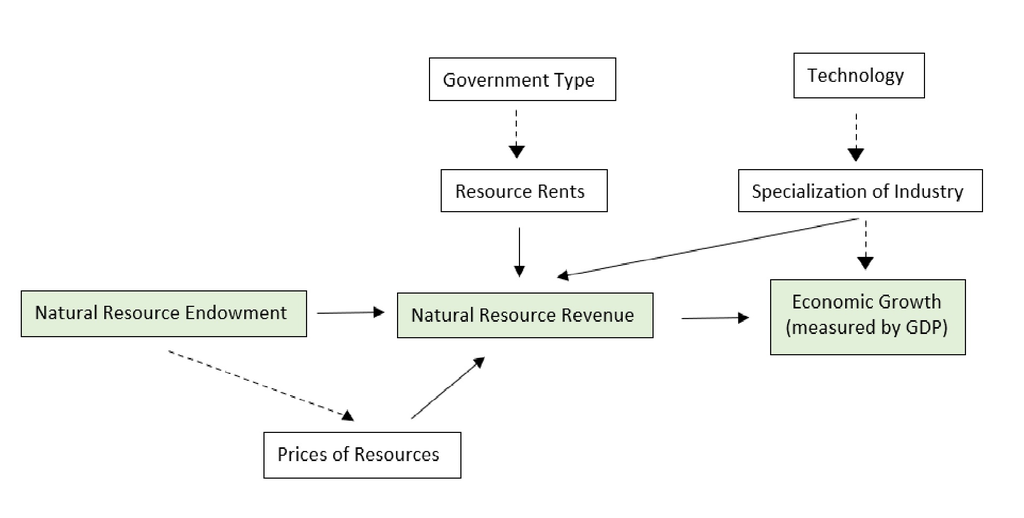

## Data

The data necessary to assess our argument is compiled into six essential pieces of data:

1. Statistics of resource endowment, detailing which resource each country has and the percent of exports
2. GDP growth (and reductions) since exporting natural resources
3. GDP per capita growth (and reductions) since exporting natural resources
4. Prices of the natural resources before and after exportation
5. Government rents from natural resources and their factor of total GDP/production
6. Exports and Natural Resource Exports as a percentage of Total GDP

These six factors will demonstrate how the exchange of natural resources has changed in recent years and how developing economies have responded. As outlined above, our goal is to compare the data on the total production of natural resources to GDP per capita and total GDP growth to measure whether correlations exist between the two variables. The prices of the resources and the government rents will serve as control variables, to test whether extreme variation in GDP comes from internal or external factors. Due to a large number of confounding variables, we chose two external factors (price and government rents) to measure internal and external pressure on the market at all times.

Ultimately, these variables will address the factors of economic growth and demonstrate how resource-rich countries are at a unique disadvantage: despite an ingrained source for wealth, the countries are failing to develop or to grow.

### Source of the Data

Most of our data can be sources from either OEC, the IMF, and the World Bank. However, some data is incomplete or unreliable. By using international market price and reported government rents of minerals, we hope to limit the effect of unreliable information.

### Goals of Analysis

With our data, we intend to demonstrate four main correlations.

1. Demonstrate a correlation between the percent of natural resource of exports and negative (OR neutral) GDP growth

Economic logic suggests that increase exports is linked to GDP growth. Therefore, a negative or neutral correlation between GDP growth and natural resource exports would illustrate some negative pressure from natural resources on GDP.

We plan to run regression to determine a correlation between natural resources as a percent of exports and GDP growth both average for countries and over time. We will also run a correlation between exports and GDP per capita growth. Ideally, both will demonstrate that peaks of prices are correlated with dips in GDP (and GDPPC) growth.

2. Demonstrating negative (OR neutral) correlation between price of natural resources and GDP per capita growth

Again, economic logic would suggest that increasing GDP and increased natural resources exports would benefit the country's population. A negative or neutral correlation suggests that the increased revenues do not go to the people, but go somewhere else. If GDPPC is stagnant, this suggests limited development and growth.

3. Illustrating a correlation between natural resources as a percent of exports and government rents

Given that natural resource have a negative pressure on GDP growth and GDPPC is stagnant, where does that extra income go? Demonstrating a correlation between natural resource dependence and rents will illustrate that in some way, governments benefit from increase prices rather than the people. Therefore, government rents would be detrimental to development and growth.

We plan to run regressions between prices of natural resources and government rent growth, as well as a regression for resource endowment as a percentage of exports and rent growth. It is crucially import to note that we plan to use region as a control variable for these regressions. Regions that are more authoritarian than others (like the Middle East) will naturally have higher resource rents than democratic regions (like Europe or Africa). However, all regions should show negative trends. Therefore, by keeping region as a control variable, we will ensure that no data is skewed by government type or regional diversity.

and lastly,

4. Illustrating the general correlation between high resource endowment and GDP growth over time

Using the data compiled previously, we hope to illustrate how resource endowment has an overwhelmingly negative impact of GDP growth and GDPPC growth. These variables demonstrate the various factors of the economy which are influenced by resource endowment and those which are negatively impacted.

Our outputs will be linear regression dynamic models and several R2 data analyses. Particularly for regressions over time, we intend to use linear regressions to show correlations between variables.

**Country Selection**

We chose our countries from the IMF(2012) Data set. These countries were chosen as "resource-rich" as natural resources account for 20%+ of exports or 20%+ of fiscal revenue.

This data set is organized by GNI per capita from lowest to highest. We excluded the rising natural resource exporters due to a lack of reliable information across several data banks. Information not included in the IMF Data Set was acquired through OEC data banks.  
Based on some of our preliminary regression, some countries are still missing information despite using multiple resources. For the final project, we hope to find some of the missing data. Otherwise, we will note which countries are missing. We speculate the some of the missing data is either due to government secrecy or inaccessibility to information in smaller or more authoritarian countries.

```python
# our list of countries and their primary exports
cpd
```

|  | Country Name | iso3c | Exports | NR_TE | Dependence_Deg |
| --- | --- | --- | --- | --- | --- |
| 0 | Congo, Dem. Rep | COD | Minerals & Oil | 94 | Dependent |
| 1 | Liberia | LBR | Gold/Iron Ore | 35 | Medium |
| 2 | Niger | NER | Gold/Oil/Uranium | 79 | Dependent |
| 3 | Guinea | GIN | Mining Products | 93 | Dependent |
| 4 | Mali | MLI | Gold | 75 | High |
| 5 | Chad | TCD | Oil | 89 | Dependent |
| 6 | Mauritania | MRT | Iron Ore | 24 | Medium |
| 7 | Lao PDR | LAO | Copper & Gold | 57 | High |
| 8 | Zambia | ZMB | Copper | 72 | High |
| 9 | Vietnam | VNM | Oil | 14 | Low |
| 10 | Yemen | YEM | Oil | 82 | Dependent |
| 11 | Nigeria | NGA | Oil | 97 | Dependent |
| 12 | Cameroon | CMR | Oil | 47 | Medium |
| 13 | Papua New Guinea | PNG | Oil/Copper/Gold | 77 | Dependent |
| 14 | Sudan | SDN | Oil | 97 | Dependent |
| 15 | Uzbekistan | UZB | Gold/Oil | 54 | High |
| 16 | Cote d'Ivoire | CIV | Oil/Gold | 17 | Low |
| 17 | Bolivia | BOL | Oil | 74 | High |
| 18 | Mongolia | MNG | Copper | 81 | Dependent |
| 19 | Congo, Rep. of | COG | Oil | 90 | Dependent |
| 20 | Iraq | IRQ | Oil | 99 | Dependent |
| 21 | Indonesia | IDN | Oil | 10 | Low |
| 22 | Timor Leste | TLS | Oil | 99 | Dependent |
| 23 | Syrian Arab Republic | SYR | Oil | 36 | Medium |
| 24 | Guyana | GUY | Gold & Bauxite | 42 | Medium |
| 25 | Turkmenistan | TKM | Oil | 91 | Dependent |
| 26 | Angola | AGO | Oil | 95 | Dependent |
| 27 | Gabon | GAB | Oil | 83 | Dependent |
| 28 | Equatorial Guinea | GNQ | Oil | 99 | Dependent |
| 29 | Ecuador | ECU | Oil | 55 | High |
| 30 | Albania | ALB | Oil | 10 | Low |
| 31 | Algeria | DZA | Oil | 98 | Dependent |
| 32 | South Africa | ZAF | Minerals | 55 | High |
| 33 | Iran | AZE | Oil | 94 | Dependent |
| 34 | Peru | PER | Minerals | 48 | Medium |
| 35 | Brazil | BRA | Oil/Iron | 26 | Low |
| 36 | Azerbaijan | AZE | Oil | 94 | Dependent |
| 37 | Botswana | BWA | Diamonds | 66 | High |
| 38 | Kazakhstan | KAZ | Oil | 60 | High |
| 39 | Suriname | SUR | Minerals | 11 | Low |
| 40 | Mexico | MEX | Oil | 15 | Low |
| 41 | Russia | RUS | Oil/Minerals | 61 | High |
| 42 | Chile | CHL | Copper | 53 | High |
| 43 | Venezuela | VEN | Oil | 93 | Dependent |
| 44 | Libya | LBY | Oil | 97 | Dependent |
| 45 | Bahrain | BHR | Oil | 96 | Dependent |
| 46 | Brunei Darussalam | BRN | Oil | 87 | Dependent |
| 47 | Trinidad and Tobago | TTO | Oil | 38 | Medium |
| 48 | Saudi Arabia | SAU | Oil | 87 | Dependent |
| 49 | Oman | OMN | Oil | 73 | High |
| 50 | United Arab Emirates | UAE | Oil | 41 | Medium |
| 51 | Qatar | QAT | Oil | 88 | Dependent |
| 52 | Norway | NOR | Oil | 62 | High |

**Compilation of Data** Combining the IMF and OEC data set with the WDI data

```python
wdi = wb.download(indicator=wdi_indicators, country=wbcountries.iso2c.values, start=1950, end=year)
wdi = wdi.reset_index()
wdi['year'] = wdi.year.astype(int)
#GDP Per Capita
wdi['gdp_pc'] = wdi['NY.GDP.PCAP.PP.KD']
wdi['ln_gdppc']= wdi['gdp_pc'].apply(np.log)
#GDP growth annually
wdi['GDP_grow'] = wdi['NY.GDP.MKTP.KD.ZG']
wdi['ln_GDP_grow'] = wdi['NY.GDP.MKTP.KD.ZG'].apply(np.log)
#GPD Per Capita growth annually
wdi['GDPPC_grow'] = wdi['NY.GDP.PCAP.KD.ZG']
#Oil Rents as a percentage of GDP
wdi['OR'] = wdi['NY.GDP.PETR.RT.ZS']
wdi['ln_OR'] = wdi['OR'].apply(np.log)
#Natural resource rents as a percentage of GDP
wdi['NRR'] = wdi['NY.GDP.TOTL.RT.ZS']
wdi['ln_NRR']=wdi['NY.GDP.TOTL.RT.ZS'].apply(np.log)
#Exports as a percentage of GDP
wdi['Exports_TR'] = wdi['NE.EXP.GNFS.ZS']
#Price of Oil
wdi['POil'] = wdi['EP.PMP.SGAS.CD']
wdi['POil_chg']=wdi['POil'].pct_change()

wdi
```

|  | country | year | NY.GDP.MKTP.KD.ZG | NY.GDP.PCAP.KD.ZG | NY.GDP.PETR.RT.ZS | NE.EXP.GNFS.ZS | NY.GDP.TOTL.RT.ZS | NY.GDP.PCAP.PP.KD | EP.PMP.SGAS.CD | gdp_pc | ... | GDP_grow | ln_GDP_grow | GDPPC_grow | OR | ln_OR | NRR | ln_NRR | Exports_TR | POil | POil_chg |
| --- | --- | --- | --- | --- | --- | --- | --- | --- | --- | --- | --- | --- | --- | --- | --- | --- | --- | --- | --- | --- | --- |
| 0 | Aruba | 2020 | -22.318948 | -22.650725 | NaN | 56.545088 | NaN | 29563.756955 | NaN | 29563.756955 | ... | -22.318948 | NaN | -22.650725 | NaN | NaN | NaN | NaN | 56.545088 | NaN | NaN |
| 1 | Aruba | 2019 | -2.085600 | -2.512957 | NaN | 74.582278 | NaN | 38221.117314 | NaN | 38221.117314 | ... | -2.085600 | NaN | -2.512957 | NaN | NaN | NaN | NaN | 74.582278 | NaN | NaN |
| 2 | Aruba | 2018 | 1.267218 | 0.803198 | 0.0 | 73.796232 | 0.001875 | 39206.356147 | NaN | 39206.356147 | ... | 1.267218 | 0.236824 | 0.803198 | 0.0 | -inf | 0.001875 | -6.279193 | 73.796232 | NaN | NaN |
| 3 | Aruba | 2017 | 5.482371 | 4.985800 | 0.0 | 72.556459 | 0.002827 | 38893.960556 | NaN | 38893.960556 | ... | 5.482371 | 1.701538 | 4.985800 | 0.0 | -inf | 0.002827 | -5.868554 | 72.556459 | NaN | NaN |
| 4 | Aruba | 2016 | 2.116716 | 1.604501 | 0.0 | 71.821756 | 0.003344 | 37046.877414 | NaN | 37046.877414 | ... | 2.116716 | 0.749866 | 1.604501 | 0.0 | -inf | 0.003344 | -5.700610 | 71.821756 | NaN | NaN |
| ... | ... | ... | ... | ... | ... | ... | ... | ... | ... | ... | ... | ... | ... | ... | ... | ... | ... | ... | ... | ... | ... |
| 13232 | Zimbabwe | 1964 | -1.106172 | -4.403385 | NaN | NaN | NaN | NaN | NaN | NaN | ... | -1.106172 | NaN | -4.403385 | NaN | NaN | NaN | NaN | NaN | NaN | 0.0 |
| 13233 | Zimbabwe | 1963 | 6.244345 | 2.697117 | NaN | NaN | NaN | NaN | NaN | NaN | ... | 6.244345 | 1.831676 | 2.697117 | NaN | NaN | NaN | NaN | NaN | NaN | 0.0 |
| 13234 | Zimbabwe | 1962 | 1.434471 | -1.934893 | NaN | NaN | NaN | NaN | NaN | NaN | ... | 1.434471 | 0.360796 | -1.934893 | NaN | NaN | NaN | NaN | NaN | NaN | 0.0 |
| 13235 | Zimbabwe | 1961 | 6.316157 | 2.821534 | NaN | NaN | NaN | NaN | NaN | NaN | ... | 6.316157 | 1.843111 | 2.821534 | NaN | NaN | NaN | NaN | NaN | NaN | 0.0 |
| 13236 | Zimbabwe | 1960 | NaN | NaN | NaN | NaN | NaN | NaN | NaN | NaN | ... | NaN | NaN | NaN | NaN | NaN | NaN | NaN | NaN | NaN | 0.0 |

13237 rows × 21 columns